# asinh(mean(x)) vs mean(asinh(x))

2022-12-07

The following examines the difference between mean(asinh(x/5)) and asinh(mean(x/5)). For the scope of this markdown, when I say “mean” I mean “arithmetic mean.”

First, we make some toy data. I take 10,000 instances 100 normally distributed data points (think 10,000 clusters). To make the data CyTOF-like (more log-normal-like), I do the inverse of the standard asinh(x/5) transformation for CyTOF data.

```r
library(tidyverse)
rand_list <- lapply(1:10000, function(i) rnorm(100, mean = 5, sd = 2))
rand_list <- lapply(rand_list, function(i) sinh(i)*5)
rand_list[1:3]
```

```
## [[1]]
##   [1]  1746.0757536   420.2970402   281.1666214   524.9709878    56.5013780
##   [6]   403.5724889    15.9439362 58095.4671170 26432.2422277    72.4213880
##  [11]   959.8826441   357.0029326   525.9660021   528.3548157    34.4592987
##  [16]  3152.5255679   252.3495527   553.5552746  1730.5754956   324.1488566
##  [21]   440.0371066     5.5486396   165.6549788    64.8685427   215.5503969
##  [26]   113.9300958  1978.7456439  6031.5067267    54.7363505    38.9923806
##  [31]  5874.7021037  1838.2045899   467.4419724  1557.5076455  1119.8460847
##  [36]   662.5377975   608.8868651  1658.1743909  8608.0498159  2896.1920858
##  [41]  2496.8366735   434.2369688 11988.7139791    69.0725255   891.7047822
##  [46]   243.6850210    66.4701989 89906.7764213  3912.7853885    92.9448296
##  [51]    34.6368336    24.3939101    71.4034468    22.1461634   608.6268410
##  [56]  1792.0376446 10495.7521424     3.5288467  4323.1397068   142.2619409
##  [61]     5.1177573   369.9936541    17.2541253   299.6243381   884.3247160
##  [66]    69.0902181     6.9665513   141.8996084     7.0812145   272.3181236
```

[output cut: 50 more lines]

We then do the asinh(mean(x/5)) and the mean(asinh(x/5)), storing them as separate vectors.

```r
x <- lapply(rand_list, function(i) asinh(mean(i)/5)) %>% unlist()
x[1:10]
```

```
##  [1] 7.118008 7.348267 6.137893 6.836156 6.772216 6.562271 6.530395 6.623748
##  [9] 7.323337 6.884612
```

```r
y <- lapply(rand_list, function(i) mean(asinh(i/5))) %>% unlist()
y[1:10]
```

```
##  [1] 5.054472 5.230885 4.667892 5.251546 5.073105 4.910224 5.020283 4.914269
##  [9] 5.131838 5.092842
```

We next check the correlation between the data transformed by the two operations, and do a simple biaxial plot.

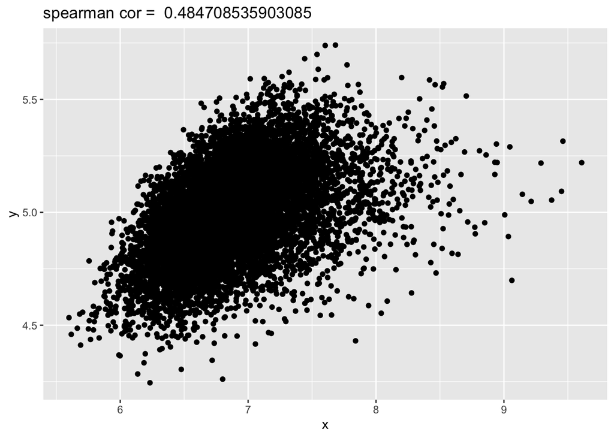

```r
library(ggplot2)
scor <- cor(x, y, method = "spearman")
qplot(x, y) + ggtitle(paste("spearman cor = ", scor))
```

Finally, we view each vector separately. We note than the mean of the asinh transformed data form a bell curve, whereas the asinh of the mean of the raw data form a distribution that has a tail to the right.

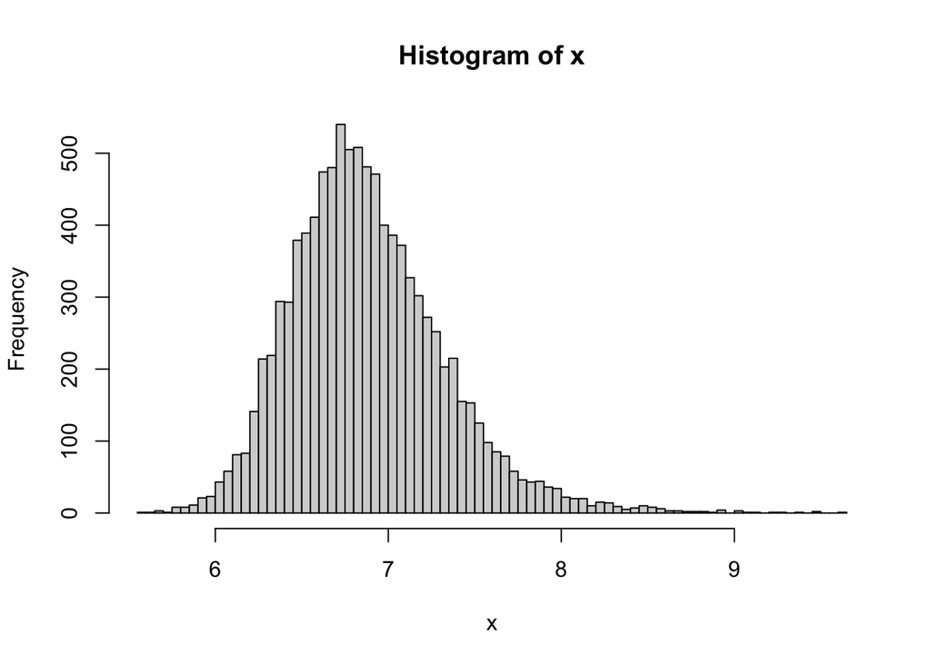

```r
hist(x, breaks = 100) # asinh of the mean
```

```r
summary(x)
```

```
##    Min. 1st Qu.  Median    Mean 3rd Qu.    Max.
##   5.599   6.578   6.830   6.879   7.130   9.608
```

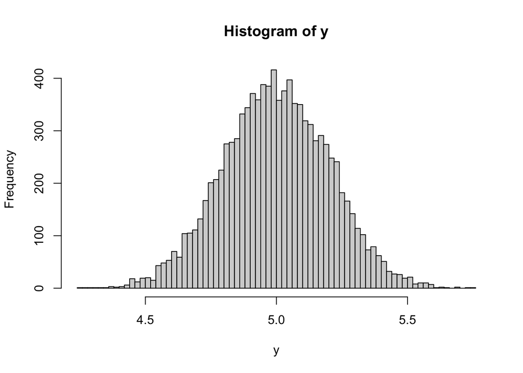

```r
hist(y, breaks = 100) # mean of the asinh (this is what omiq exports by default)
```

```r
summary(y)
```

```
##    Min. 1st Qu.  Median    Mean 3rd Qu.    Max.
##   4.245   4.862   4.997   4.999   5.138   5.741
```

Finally, what is the verbal explanation as to why you should take the mean of the asinh transformed data, and not the asinh of the mean of the raw data? Because the raw data are skewed, and the asinh transformation makes the data more normal distribution-like. Taking the mean gives you better intuition around a normal distribution than a skewed distribution. In the latter case, you have to deal with outliers on the right affecting the value of the mean. For skewed distributions and for outliers in general, there are other operations, like the geometric mean, that may be more appropriate here. But that’s outside of the scope of this markdown.